# PML Assignment

Haluca

10 februari 2016

## Assignment

The goal of this project is to predict how well participants do a particular activity using data from accelerometers on the belt, forearm, arm, and dumbell. Training data is given with a “classe” variable pointng out how well th exercise is done. The formed model will be used to predict this ‘classe’ for 20 different test cases.

## Background

Using devices such as Jawbone Up, Nike FuelBand, and Fitbit it is now possible to collect a large amount of data about personal activity relatively inexpensively. These type of devices are part of the quantified self movement - a group of enthusiasts who take measurements about themselves regularly to improve their health, to find patterns in their behavior, or because they are tech geeks. One thing that people regularly do is quantify how much of a particular activity they do, but they rarely quantify how well they do it. In this project, your goal will be to use data from accelerometers on the belt, forearm, arm, and dumbell of 6 participants. They were asked to perform barbell lifts correctly and incorrectly in 5 different ways. More information is available from the website here: http://groupware.les.inf.puc-rio.br/har (see the section on the Weight Lifting Exercise Dataset).

The training data for this project are available here: https://d396qusza40orc.cloudfront.net/predmachlearn/pml-training.csv  
The test data are available here: https://d396qusza40orc.cloudfront.net/predmachlearn/pml-testing.csv

The data for this project come from this source: http://groupware.les.inf.puc-rio.br/har.

## Reading, Exploring and Cleaning Data

```r
  train<-read.csv("./pml-training.csv")
```

Investigating the data, we discover a lot of spaces and null values.  
For easy cleaning the we decide to convert all values “NA”, spaces and “NULL” to “NA”.

```r
  train<-read.csv("./pml-training.csv", na.strings=c("NA","","NULL"))
  test<-read.csv("./pml-testing.csv", na.strings=c("NA","","NULL"))
  dim(train);dim(test)
```

```
## [1] 19622   160
```

```
## [1]  20 160
```

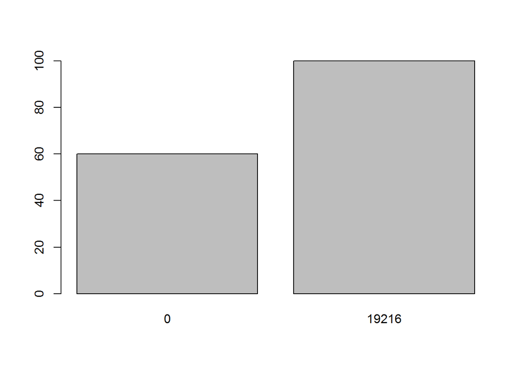

```r
  plot(as.factor(colSums(is.na(train))))
```

Examining further we see 60 columns with no ‘NA’ value, and 100 columns existing mainly off ‘NA’ (19216 NA’s). We’ll continue with the columns with no ‘NA’.  
Also we delete the columns we don’t consider relevant for the prediction: ‘X’, ‘user_name’, ‘raw_timestamp_part_1’, ‘raw_timestamp_part_2’, ‘cvtd_timestamp’, ‘new_window’, ‘num_window’.  
The same deletions are done for the testset.

```r
  trainclean<-train[,colSums(is.na(train))==0]
  trainclean<-trainclean[,8:60]
  testclean<-test[,colSums(is.na(test))==0]
  testclean<-testclean[,8:60]
  dim(trainclean);dim(testclean)
```

```
## [1] 19622    53
```

```
## [1] 20 53
```

Let us make a correlationplot of the remaining columns. (excluding the ‘classe’ column).  
Using the corrplot-function in the corrplot-package we plot the data, centered and scaled.

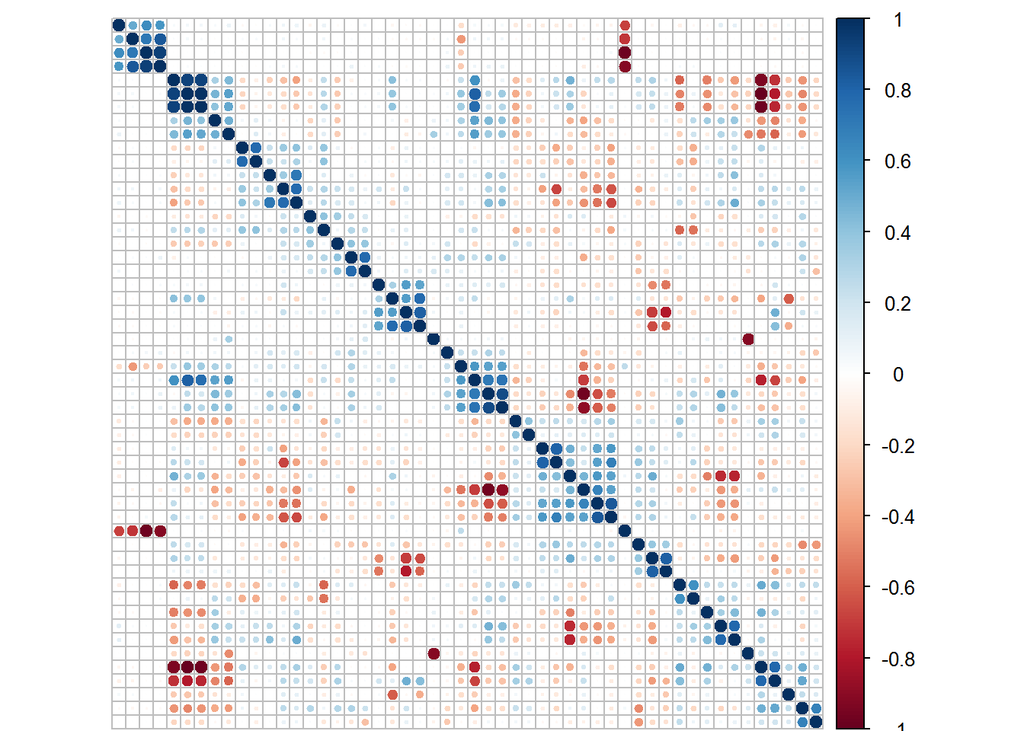

```r
  library(corrplot)
  trainscale<- scale(trainclean[,-53],center=TRUE,scale=TRUE);
  corcols<- cor(trainscale)
  corrplot(corcols, order = "hclust", tl.pos="n")
```

The plot shows high correlation between some variables.

## preprocessing, modelling, testing model

We reduce pair-wise correlations by removing columns. The findCorrelation function in the caret-package is used to determine the columns and delete them.

```r
  library(caret)
  traincor = cor(trainclean[,-53])
  corcols = findCorrelation(traincor, cutoff=0.9)
  trainexcor = trainclean[,-c(corcols)]
  testexcor = testclean[,-c(corcols)]
  dim(trainexcor);dim(testexcor)
```

```
## [1] 19622    46
```

```
## [1] 20 46
```

```r
  set.seed(12345)
  intrain<-createDataPartition(trainexcor$classe,p=0.75,list=FALSE)
  training<-trainexcor[intrain,]
  testing<-trainexcor[-intrain,]

  set.seed(54321)
  trainControl(method="cv")
  modrf <- train(classe ~ .,method="rf",data=training)
```

How good is the model? Using our testingset We compare the predicted classe-value with the real ones.

```r
  predtest=predict(modrf,testing)
  sum(predtest==testing$classe)/length(predtest)
```

```
## [1] 0.9934747
```

```r
  confusionMatrix(predtest, testing$classe)
```

```
## Confusion Matrix and Statistics
##
##           Reference
## Prediction    A    B    C    D    E
##          A 1393    8    0    0    0
##          B    2  938    4    0    0
##          C    0    3  848    6    2
##          D    0    0    3  798    4
##          E    0    0    0    0  895
##
## Overall Statistics
##
##                Accuracy : 0.9935
##                  95% CI : (0.9908, 0.9955)
##     No Information Rate : 0.2845
##     P-Value [Acc > NIR] : < 2.2e-16
##
##                   Kappa : 0.9917
##  Mcnemar's Test P-Value : NA
##
## Statistics by Class:
##
##                      Class: A Class: B Class: C Class: D Class: E
## Sensitivity            0.9986   0.9884   0.9918   0.9925   0.9933
## Specificity            0.9977   0.9985   0.9973   0.9983   1.0000
## Pos Pred Value         0.9943   0.9936   0.9872   0.9913   1.0000
## Neg Pred Value         0.9994   0.9972   0.9983   0.9985   0.9985
## Prevalence             0.2845   0.1935   0.1743   0.1639   0.1837
## Detection Rate         0.2841   0.1913   0.1729   0.1627   0.1825
## Detection Prevalence   0.2857   0.1925   0.1752   0.1642   0.1825
## Balanced Accuracy      0.9981   0.9934   0.9945   0.9954   0.9967
```

The model showes an accuracy of 99.35%, with a 95% confidence interval between .9908 and .9955.  
That is pretty good. We are not tuning any further, trying other methods, preprocessing technics or combinations.

## predicting outcome

Finally let us predict the outcome of the downloaded, cleaned, set with testcases.

```r
  outcome<-predict(modrf,testexcor)
  outcome
```

```
##  [1] B A B A A E D B A A B C B A E E A B B B
## Levels: A B C D E
```